# **Recommended Systems Project Solution**

• DOMAIN: Smartphone, Electronics

• CONTEXT: India is the second largest market globally for smartphones after China. About 134 million smartphones were sold across India in the year 2017 and is estimated to increase to about 442 million in 2022. India ranked second in the average time spent on mobile web by smartphone users across Asia Pacific. The combination of very high sales volumes and the average smartphone consumer behaviour has made India a very attractive market for foreign vendors. As per Consumer behaviour, 97% of consumers turn to a search engine when they are buying a product vs. 15% who turn to social media. If a seller succeeds to publish smartphones based on user’s behaviour/choice at the right place, there are 90% chances that user will enquire for the same. This Case Study is targeted to build a recommendation system based on individual consumer’s behaviour or choice.

• DATA DESCRIPTION:

- author : name of the person who gave the rating
- country : country the person who gave the rating belongs to
- data : date of the rating
- domain: website from which the rating was taken from
- extract: rating content
- language: language in which the rating was given
- product: name of the product/mobile phone for which the rating was given
- score: average rating for the phone
- score_max: highest rating given for the phone
- source: source from where the rating was taken

• PROJECT OBJECTIVE: We will build a recommendation system using popularity based and collaborative filtering methods to recommend mobile phones to a user which are most popular and personalised respectively.

## **1. Import the necessary libraries and read the provided CSVs as a data frame and perform the below steps.**

```python
# Import all the necessary libraries.
import pandas as pd
import numpy as np
import seaborn as sns
import matplotlib.pyplot as plt
%matplotlib inline
```

```python
df1 = pd.read_csv("phone_user_review_file_1.csv", encoding='latin1')
df2 = pd.read_csv("phone_user_review_file_2.csv", encoding='latin1')
df3 = pd.read_csv("phone_user_review_file_3.csv", encoding='latin1')
df4 = pd.read_csv("phone_user_review_file_4.csv", encoding='latin1')
df5 = pd.read_csv("phone_user_review_file_5.csv", encoding='latin1')
df6 = pd.read_csv("phone_user_review_file_6.csv", encoding='latin1')
```

```python
print('Shape of DataFrame 1', df1.shape)
print('Shape of DataFrame 2', df2.shape)
print('Shape of DataFrame 3', df3.shape)
print('Shape of DataFrame 4', df4.shape)
print('Shape of DataFrame 5', df5.shape)
print('Shape of DataFrame 6', df6.shape)
```

```
Shape of DataFrame 1 (374910, 11)
Shape of DataFrame 2 (114925, 11)
Shape of DataFrame 3 (312961, 11)
Shape of DataFrame 4 (98284, 11)
Shape of DataFrame 5 (350216, 11)
Shape of DataFrame 6 (163837, 11)
```

**A. Merge all the provided CSVs into one dataFrame.**

```python
data  = [df1,df2,df3,df4,df5,df6]
ph_df = pd.concat(data)
print('Shape of Merged DataFrame', ph_df.shape)
```

```
Shape of Merged DataFrame (1415133, 11)
```

**B. Explore, understand the Data and share at least 2 observations.**

```python
ph_df.head(5)
```

|  | phone_url | date | lang | country | source | domain | score | score_max | extract | author | product |
| --- | --- | --- | --- | --- | --- | --- | --- | --- | --- | --- | --- |
| 0 | /cellphones/samsung-galaxy-s8/ | 5/2/2017 | en | us | Verizon Wireless | verizonwireless.com | 10.0 | 10.0 | As a diehard Samsung fan who has had every Sam... | CarolAnn35 | Samsung Galaxy S8 |
| 1 | /cellphones/samsung-galaxy-s8/ | 4/28/2017 | en | us | Phone Arena | phonearena.com | 10.0 | 10.0 | Love the phone. the phone is sleek and smooth ... | james0923 | Samsung Galaxy S8 |
| 2 | /cellphones/samsung-galaxy-s8/ | 5/4/2017 | en | us | Amazon | amazon.com | 6.0 | 10.0 | Adequate feel. Nice heft. Processor's still sl... | R. Craig | Samsung Galaxy S8 (64GB) G950U 5.8" 4G LTE Unl... |
| 3 | /cellphones/samsung-galaxy-s8/ | 5/2/2017 | en | us | Samsung | samsung.com | 9.2 | 10.0 | Never disappointed. One of the reasons I've be... | Buster2020 | Samsung Galaxy S8 64GB (AT&T) |
| 4 | /cellphones/samsung-galaxy-s8/ | 5/11/2017 | en | us | Verizon Wireless | verizonwireless.com | 4.0 | 10.0 | I've now found that i'm in a group of people t... | S Ate Mine | Samsung Galaxy S8 |

**Check Data Type of the features**

```python
ph_df.info()
```

```
<class 'pandas.core.frame.DataFrame'>
Int64Index: 1415133 entries, 0 to 163836
Data columns (total 11 columns):
 #   Column     Non-Null Count    Dtype
---  ------     --------------    -----
 0   phone_url  1415133 non-null  object
 1   date       1415133 non-null  object
 2   lang       1415133 non-null  object
 3   country    1415133 non-null  object
 4   source     1415133 non-null  object
 5   domain     1415133 non-null  object
 6   score      1351644 non-null  float64
 7   score_max  1351644 non-null  float64
 8   extract    1395772 non-null  object
 9   author     1351931 non-null  object
 10  product    1415132 non-null  object
dtypes: float64(2), object(9)
memory usage: 129.6+ MB
```

**Observation:**

Most of the features are Object type except score and score_max which are float data types.

```python
ph_df.describe().T
```

|  | count | mean | std | min | 25% | 50% | 75% | max |
| --- | --- | --- | --- | --- | --- | --- | --- | --- |
| score | 1351644.0 | 8.00706 | 2.616121 | 0.2 | 7.2 | 9.2 | 10.0 | 10.0 |
| score_max | 1351644.0 | 10.00000 | 0.000000 | 10.0 | 10.0 | 10.0 | 10.0 | 10.0 |

**Check for NULL Values**

```python
(ph_df.isnull().sum()/len(ph_df))*100
```

```
phone_url    0.000000
date         0.000000
lang         0.000000
country      0.000000
source       0.000000
domain       0.000000
score        4.486433
score_max    4.486433
extract      1.368140
author       4.466153
product      0.000071
dtype: float64
```

**Observation:**

score, score_max, extract, author, product have NULL values and need to be handled.

**Check for duplicate values**

```python
# Count how many duplicates are present in the dataframe
ph_df.duplicated().sum()
```

```
6412
```

```python
#Check unique values of each columns
print("Unique Values of Columns:\n")
for column in set(ph_df.columns) - {'date', 'author'}:
    print('{:<20s} \t-  {}'.format(column,ph_df[column].unique()))
```

```
Unique Values of Columns:

source               	-  ['Verizon Wireless' 'Phone Arena' 'Amazon' 'Samsung' 'Very' 'CNET'
 'Wireless AT&T' 'Littlewoods' 'Bit.au' 'Smartprix' 'Zap.il'
 'Verkkokauppa' 'Ciao' 'Komplett.no' 'Coolblue' 'ElkjÃ¸p' 'Tkat' 'Wehkamp'
 'CZC' 'KIESKEURIG' 'Elgiganten' 'Wisebuy' 'MPX' 'Phone House' 'Inet'
 'Gigantti' 'Komplett.se ' 'Zoom.br' 'LDLC' 'Walmart' 'Ð¡Ð²Ñ\x8fÐ·Ð½Ð¾Ð¹'
 'Otzyvua' 'Mobi Guru' 'Phone Scoop' 'HSN' 'Optus' 'Kabum' 'Samsung Fun'
 'Fnac' 'Meilleur Mobile' 'Prisjakt' 'Cissa Magazine' 'Yandex' 'Ofertou'
 'Pixmania' 'BalÃ£o da InformÃ¡tica' 'CDON' 'MVideo' 'Irecommend'
 'SmartPhoneShop' 'Hotline.ua' 'Alza' 'RueDuCommerce' 'Centralpoint'
 'Portable Gear' 'LesMobiles' 'JB Hi-Fi' 'The Good Guys' 'John Lewis'
 'Otto.de' 'Vandenborre' 'Newegg' 'Staples' 'Overstock' "Sam's Club"
 'Target' 'Argos' 'B&H Photo' 'Costco' 'Rogers' 'PriceSpy' '91 Mobiles'
 'Handtec' 'Bol.com' 'Bondfaro' 'NetonNet' 'NetOnNet' 'Orange' 'Oldi'
 'Moviles' 'RedCoon' 'Lefdal' 'Belsimpel' 'Ubaldi' 'Siba' 'Media Markt'
 'Wupti' 'Ð\xadÐ»ÐµÐºÑ\x82Ñ\x80Ð¾Ð½Ð½Ñ\x8bÐ¹ Ð¼Ð¸Ñ\x80' 'Priceminister'
 'Cyberport' 'Vatan Computer' 'MyTrendyPhone' 'Grosbill' 'GSMinfo.nl  '
 'Komplett.dk ' 'Typhone' 'Digitec' 'Tweakers.net' 'Monclick' 'Ulmart'
 'Materiel.net' 'Ð¡Ð¸Ñ\x82Ð¸Ð»Ð¸Ð½Ðº' '21vek.by' 'ABT Electronics'
 'Currys' 'Zopper' 'Cdiscount' 'Casas Bahia' 'Conrad' 'Media Markt '
 'Eldorado' 'PriceCheck' 'Clove' 'Mister Good Deal' 'Wallashops'
 'OlcsÃ³bbat' 'Milky.nl' 'Cepworld' 'Snapdeal' 'QVC' 'InfiBeam' 'Rakuten'
 'Fotosidan' 'Geizhals.de' 'Inside-handy' 'Winnie Kepala' 'Hit Meister'
 'Macway' 'DNS' 'Hintaseuranta' 'Dooyoo' 'Bellen.com' 'Linio' 'Souq'
 'Comparateur' 'Webhallen' 'City Key' 'Computers in South Africa'
 'Ainol-novo' 'RC Willey' 'Magazine Luiza' 'MTS.ru' 'Phonehouse'
 'LG Electronics' 'LG' 'Huawei' 'Katshing' 'NCIX.com ' 'Bhinneka'
 'Flipkart' 'Kasa' 'Linio Venezuela' 'Mall.cz' 'Halebop' 'Ceptown'
 'ALTERNATE' 'Dino Direct' 'Overclock' '3 Suisses' 'TestMateriel'
 'Conforama' 'Geekvida' 'PB Tech' 'Octilus' 'Colombo' 'Quesabesde'
 'Plus.de' 'Ð¢ÐµÑ\x85Ð½Ð¾Ð\x9fÐ¾Ñ\x80Ñ\x82Ð°Ð»' 'Meinpaket'
 'El Corte InglÃ©s' ' SHOP' 'DWI' 'Conrad Elektronik' 'Euronics' 'Efox'
 'Submarino' 'Arukereso.hu' 'MicrosoftStore' 'ReviewStream'
 'Consumenten Bond' 'Shoptime' 'Americanas' 'Onliner' 'Mob.org' 'SFR'
 'Sears' 'MobileZap' 'Microsoft Store' '24 Shop' 'PDA Shop' 'Homeshop18'
 'Shop Fato' 'PriceRunner' 'Ð\x9cÐµÑ\x82Ð°Ð\x9cÐ°Ñ\x80ÐºÐµÑ\x82' 'Darty'
 'Vergelijk' 'Naaptol' 'Otzovik' 'HTC' 'eBay' 'Extra' 'Girafa'
 'Hepsiburada' 'Cimri' 'Notebooksbilliger' 'Mobile fun' 'Shopping-UOL'
 'Forum Celular' 'Office Depot' 'Shop Your Way' 'Vodafone' 'Mighty Ape'
```

[output cut: 134 more lines]

```
 'Alcatel Club Plus Handy']
country              	-  ['us' 'gb' 'au' 'in' 'il' 'fi' 'it' 'no' 'nl' 'ru' 'cz' 'be' 'se' 'es'
 'br' 'fr' 'ua' 'ca' 'de' 'dk' 'nz' 'tr' 'pl' 'ch' 'pt' 'hu' 'za' 'mx'
 'ae' 'id' 've' 'sg' 'cl' 'ar' 'ec' 'tw' 'co' 'jp' 'uy' 'pe' 'cn' 'kr']
score                	-  [10.   6.   9.2  4.   8.   2.   9.6  7.2  6.8  9.   8.3  8.8  8.4  5.3
  7.   6.4  7.6  nan  5.2  3.2  4.4  2.8  5.6  3.6  4.8  1.   5.   3.
  2.4  9.3  8.5  9.5  6.5  5.5  9.8  8.2  8.6  7.8  9.4  6.6  6.2  7.5
  9.9  2.7  8.7  6.7  3.3  7.7  7.3  9.7  6.3  7.4  5.7  4.7  4.3  5.8
  4.2  4.5  2.2  5.4  7.9  3.5  4.6  3.7  2.5  3.4  7.1  8.1  1.2  1.4
  3.8  9.1  2.6  1.6  1.7  1.5  1.8  2.3  6.1  5.9  1.3  0.2  0.4  8.9
  6.9  0.6  4.9]
phone_url            	-  ['/cellphones/samsung-galaxy-s8/'
 '/cellphones/samsung-galaxy-s6-edgeplus/'
 '/cellphones/samsung-galaxy-s8-plus/' ... '/cellphones/siemens-c10/'
 '/cellphones/maxon-mx-3204/' '/cellphones/alcatel-ot-club_1187/']
```

```python
import re
def replace_foreign_characters(s):
    return re.sub(r'[^\x00-\x7f]',r'', s)

ph_df['source'] = ph_df['source'].apply(lambda x: replace_foreign_characters(x))
```

```python
#Check unique values of each columns
print("Unique Values of Columns:\n")
for column in set(ph_df.columns) - {'date', 'author'}:
    print('{:<20s} \t-  {}'.format(column,ph_df[column].unique()))
```

```
Unique Values of Columns:

source               	-  ['Verizon Wireless' 'Phone Arena' 'Amazon' 'Samsung' 'Very' 'CNET'
 'Wireless AT&T' 'Littlewoods' 'Bit.au' 'Smartprix' 'Zap.il'
 'Verkkokauppa' 'Ciao' 'Komplett.no' 'Coolblue' 'Elkjp' 'Tkat' 'Wehkamp'
 'CZC' 'KIESKEURIG' 'Elgiganten' 'Wisebuy' 'MPX' 'Phone House' 'Inet'
 'Gigantti' 'Komplett.se ' 'Zoom.br' 'LDLC' 'Walmart' '' 'Otzyvua'
 'Mobi Guru' 'Phone Scoop' 'HSN' 'Optus' 'Kabum' 'Samsung Fun' 'Fnac'
 'Meilleur Mobile' 'Prisjakt' 'Cissa Magazine' 'Yandex' 'Ofertou'
 'Pixmania' 'Balo da Informtica' 'CDON' 'MVideo' 'Irecommend'
 'SmartPhoneShop' 'Hotline.ua' 'Alza' 'RueDuCommerce' 'Centralpoint'
 'Portable Gear' 'LesMobiles' 'JB Hi-Fi' 'The Good Guys' 'John Lewis'
 'Otto.de' 'Vandenborre' 'Newegg' 'Staples' 'Overstock' "Sam's Club"
 'Target' 'Argos' 'B&H Photo' 'Costco' 'Rogers' 'PriceSpy' '91 Mobiles'
 'Handtec' 'Bol.com' 'Bondfaro' 'NetonNet' 'NetOnNet' 'Orange' 'Oldi'
 'Moviles' 'RedCoon' 'Lefdal' 'Belsimpel' 'Ubaldi' 'Siba' 'Media Markt'
 'Wupti' ' ' 'Priceminister' 'Cyberport' 'Vatan Computer' 'MyTrendyPhone'
 'Grosbill' 'GSMinfo.nl  ' 'Komplett.dk ' 'Typhone' 'Digitec'
 'Tweakers.net' 'Monclick' 'Ulmart' 'Materiel.net' '21vek.by'
 'ABT Electronics' 'Currys' 'Zopper' 'Cdiscount' 'Casas Bahia' 'Conrad'
 'Media Markt ' 'Eldorado' 'PriceCheck' 'Clove' 'Mister Good Deal'
 'Wallashops' 'Olcsbbat' 'Milky.nl' 'Cepworld' 'Snapdeal' 'QVC' 'InfiBeam'
 'Rakuten' 'Fotosidan' 'Geizhals.de' 'Inside-handy' 'Winnie Kepala'
 'Hit Meister' 'Macway' 'DNS' 'Hintaseuranta' 'Dooyoo' 'Bellen.com'
 'Linio' 'Souq' 'Comparateur' 'Webhallen' 'City Key'
 'Computers in South Africa' 'Ainol-novo' 'RC Willey' 'Magazine Luiza'
 'MTS.ru' 'Phonehouse' 'LG Electronics' 'LG' 'Huawei' 'Katshing'
 'NCIX.com ' 'Bhinneka' 'Flipkart' 'Kasa' 'Linio Venezuela' 'Mall.cz'
 'Halebop' 'Ceptown' 'ALTERNATE' 'Dino Direct' 'Overclock' '3 Suisses'
 'TestMateriel' 'Conforama' 'Geekvida' 'PB Tech' 'Octilus' 'Colombo'
 'Quesabesde' 'Plus.de' 'Meinpaket' 'El Corte Ingls' ' SHOP' 'DWI'
 'Conrad Elektronik' 'Euronics' 'Efox' 'Submarino' 'Arukereso.hu'
 'MicrosoftStore' 'ReviewStream' 'Consumenten Bond' 'Shoptime'
 'Americanas' 'Onliner' 'Mob.org' 'SFR' 'Sears' 'MobileZap'
 'Microsoft Store' '24 Shop' 'PDA Shop' 'Homeshop18' 'Shop Fato'
 'PriceRunner' 'Darty' 'Vergelijk' 'Naaptol' 'Otzovik' 'HTC' 'eBay'
 'Extra' 'Girafa' 'Hepsiburada' 'Cimri' 'Notebooksbilliger' 'Mobile fun'
 'Shopping-UOL' 'Forum Celular' 'Office Depot' 'Shop Your Way' 'Vodafone'
 'Mighty Ape' 'Bell' 'Ozon' 'Bimeks' 'ShopMania' 'Utinet' 'Fotos.ua'
 'ABC.ru' 'BrandsmartUSA' 'Shopclues' 'PCComponents' 'Toneto' 'Sony'
```

[output cut: 130 more lines]

```
 'Alcatel Club Plus Handy']
country              	-  ['us' 'gb' 'au' 'in' 'il' 'fi' 'it' 'no' 'nl' 'ru' 'cz' 'be' 'se' 'es'
 'br' 'fr' 'ua' 'ca' 'de' 'dk' 'nz' 'tr' 'pl' 'ch' 'pt' 'hu' 'za' 'mx'
 'ae' 'id' 've' 'sg' 'cl' 'ar' 'ec' 'tw' 'co' 'jp' 'uy' 'pe' 'cn' 'kr']
score                	-  [10.   6.   9.2  4.   8.   2.   9.6  7.2  6.8  9.   8.3  8.8  8.4  5.3
  7.   6.4  7.6  nan  5.2  3.2  4.4  2.8  5.6  3.6  4.8  1.   5.   3.
  2.4  9.3  8.5  9.5  6.5  5.5  9.8  8.2  8.6  7.8  9.4  6.6  6.2  7.5
  9.9  2.7  8.7  6.7  3.3  7.7  7.3  9.7  6.3  7.4  5.7  4.7  4.3  5.8
  4.2  4.5  2.2  5.4  7.9  3.5  4.6  3.7  2.5  3.4  7.1  8.1  1.2  1.4
  3.8  9.1  2.6  1.6  1.7  1.5  1.8  2.3  6.1  5.9  1.3  0.2  0.4  8.9
  6.9  0.6  4.9]
phone_url            	-  ['/cellphones/samsung-galaxy-s8/'
 '/cellphones/samsung-galaxy-s6-edgeplus/'
 '/cellphones/samsung-galaxy-s8-plus/' ... '/cellphones/siemens-c10/'
 '/cellphones/maxon-mx-3204/' '/cellphones/alcatel-ot-club_1187/']
```

[figure not shown]

```python
fig, ax = plt.subplots(figsize=(15, 5))
sns.set(style="darkgrid")
plt.subplot(1, 2, 1)
axes = sns.boxplot(x = ph_df["score"])
plt.subplot(1, 2, 2)
axes = sns.countplot(x = ph_df['score'])
plt.show();
```

**Observations:**

1. Score ratings are left skewed as shown in the box plot. This seems to be due to very few low ratings for some mobiles.
2. Most of the users have rated the products on higher end i.e. 8 - 10.

**C. Round off scores to the nearest integers.**

```python
ph_df['score'].unique()
```

```
array([10. ,  6. ,  9.2,  4. ,  8. ,  2. ,  9.6,  7.2,  6.8,  9. ,  8.3,
        8.8,  8.4,  5.3,  7. ,  6.4,  7.6,  nan,  5.2,  3.2,  4.4,  2.8,
        5.6,  3.6,  4.8,  1. ,  5. ,  3. ,  2.4,  9.3,  8.5,  9.5,  6.5,
        5.5,  9.8,  8.2,  8.6,  7.8,  9.4,  6.6,  6.2,  7.5,  9.9,  2.7,
        8.7,  6.7,  3.3,  7.7,  7.3,  9.7,  6.3,  7.4,  5.7,  4.7,  4.3,
        5.8,  4.2,  4.5,  2.2,  5.4,  7.9,  3.5,  4.6,  3.7,  2.5,  3.4,
        7.1,  8.1,  1.2,  1.4,  3.8,  9.1,  2.6,  1.6,  1.7,  1.5,  1.8,
        2.3,  6.1,  5.9,  1.3,  0.2,  0.4,  8.9,  6.9,  0.6,  4.9])
```

```python
ph_df['score_max'].unique()
```

```
array([10., nan])
```

```python
ph_df[['score']] = ph_df[['score']].round(0).astype('Int64')
ph_df[['score_max']] = ph_df[['score_max']].round(0).astype('Int64')
```

```python
ph_df['score'].unique()
```

```
<IntegerArray>
[10, 6, 9, 4, 8, 2, 7, 5, <NA>, 3, 1, 0]
Length: 12, dtype: Int64
```

```python
ph_df['score_max'].unique()
```

```
<IntegerArray>
[10, <NA>]
Length: 2, dtype: Int64
```

**D. Check for missing values. Impute the missing values, if any.**

```python
(ph_df.isnull().sum()/len(ph_df))*100
```

```
phone_url    0.000000
date         0.000000
lang         0.000000
country      0.000000
source       0.000000
domain       0.000000
score        4.486433
score_max    4.486433
extract      1.368140
author       4.466153
product      0.000071
dtype: float64
```

**Observation:**

score, score_max, extract, author, product have NULL values. score_max can be derived but for now, lets delete the rows having null values since dataset is huge and should not impact.

```python
ph_df.dropna(axis=0,inplace=True)
```

```python
# Verify if all NULL values are removed
(ph_df.isnull().sum()/len(ph_df))*100
```

```
phone_url    0.0
date         0.0
lang         0.0
country      0.0
source       0.0
domain       0.0
score        0.0
score_max    0.0
extract      0.0
author       0.0
product      0.0
dtype: float64
```

**E. Check for duplicate values and remove them, if any.**

```python
# Count how many duplicates are present in the dataframe
ph_df.duplicated().sum()
```

```
4480
```

```python
# Drop the duplicate rows
ph_df.drop_duplicates(inplace=True)
```

```python
# Verify if all duplicates have been removed.
ph_df.duplicated().sum()
```

```
0
```

**F. Keep only 1 Million data samples. Use random state=612.**

```python
df_1M = ph_df.sample(n=1000000, random_state = 612)
```

```python
print("Shape of Data Frame", df_1M.shape)
```

```
Shape of Data Frame (1000000, 11)
```

**G. Drop irrelevant features. Keep features like Author, Product, and Score.**

```python
df_1M = df_1M[['score','author','product']]
```

## **2. Answer the following questions.**

**A. Identify the most rated products.**

```python
df_1M.groupby("product")["score"].mean().sort_values(ascending=False).head(20)
```

```
product
'Sony Xperia X (F5122) â White â Dual Sim (Google Android 6.0.1, 5 Display, 2 x CORTEX A72 1.8 GHz + 4 x cortex-a53...       10.0
Motorola K1 On Vodafone Pay As You Go                                                                                            10.0
Motorola Droid RAZR (Red)                                                                                                        10.0
Motorola Droid RAZR 16GB XT912 4G LTE Purple - Verizon                                                                           10.0
Motorola Droid RAZR HD - 16GB - Black (Verizon) Smartphone                                                                       10.0
Motorola Droid RAZR M (Black)                                                                                                    10.0
Motorola Droid RAZR M (White)                                                                                                    10.0
Motorola Droid Turbo                                                                                                             10.0
Motorola Droid X MB810                                                                                                           10.0
Motorola E680                                                                                                                    10.0
Motorola E680i                                                                                                                   10.0
Motorola E815                                                                                                                    10.0
Motorola E815 (Verizon Wireless)                                                                                                 10.0
Motorola ELECTRIFY M                                                                                                             10.0
Motorola EX112 Telefono cellulare con fotocamera 3 MP                                                                            10.0
Motorola EX122                                                                                                                   10.0
Motorola Electrify M                                                                                                             10.0
Motorola F3 Zwart                                                                                                                10.0
Motorola G LTE - Smartphone libre Android (pantalla 4.5", cÃ¡mara 5 Mp, 8 GB, Quad-Core 1.2 GHz, 1 GB RAM), negro (importado)    10.0
Motorola GLEAM+ / PLUS / WX308 - RED - SIM FREE - UNLOCKED - UNBRANDED                                                           10.0
Name: score, dtype: Float64
```

**Observation:**

Many mobiles have mean rating of 10. However this does not take number of users who have rated into account.

**B. Identify the users with most number of reviews.**

```python
df_1M['author'].value_counts().head(10)
```

```
Amazon Customer    60408
Cliente Amazon     15051
e-bit               6651
Client d'Amazon     6087
Amazon Kunde        3683
Anonymous           2096
einer Kundin        2065
einem Kunden        1452
unknown             1350
Anonymous           1161
Name: author, dtype: int64
```

**Observation:** Amazon Customers have contributed most to the product reviews.

**C. Select the data with products having more than 50 ratings and users who have given more than 50 ratings. Report the shape of the final dataset.**

```python
df_temp = df_1M.copy(deep = True )
```

```python
df_temp.shape
```

```
(1000000, 3)
```

```python
df_temp.head()
```

|  | score | author | product |
| --- | --- | --- | --- |
| 20276 | 10 | KHILESH KUMAR VERMA | Lenovo Vibe K5 (Gold, VoLTE update) |
| 104794 | 8 | Evyta | Samsung Galaxy S6 |
| 321393 | 8 | VanRaZor | Sony Ericsson K810i |
| 78000 | 6 | ruga | Sony Xperia Z2 (Black) |
| 16933 | 10 | einer Kundin | Samsung Galaxy S7 edge Smartphone, 13,9 cm (5,... |

```python
filter1 = df_temp['author'].value_counts()
filter1 = filter1[filter1.values > 50].index.tolist()

filter2 = df_temp['product'].value_counts()
filter2 = filter2[filter2.values > 50].index.tolist()

df_final = df_temp[(df_temp["author"].isin(filter1)) & (df_temp["product"].isin(filter2))]

print("Shape of the final data set that contains users who have rated more than 50 times and the products that contain more than 50 ratings is ")
df_final.shape
```

```
Shape of the final data set that contains users who have rated more than 50 times and the products that contain more than 50 ratings is
```

```
(111595, 3)
```

## **3. Build a popularity based model and recommend top 5 mobile phones.**

```python
df_final.groupby('product')['score'].mean().sort_values(ascending=False).head()
```

```
product
3100 / 3120                  10.0
Apple iPhone 7 Plus          10.0
Lenovo S860                  10.0
Samsung Galaxy W GT-I8150    10.0
Samsung Galaxy S8+           10.0
Name: score, dtype: Float64
```

**Observation:**

The top 5 mobile recommendations are as above when the Mean rating of the product is considered. However, this may not be the right approach since it does not take number of people who have rated into consideration.

```python
df_final.groupby('product')['score'].count().sort_values(ascending=False).head()
```

```
product
Lenovo Vibe K4 Note (White,16GB)       2452
Lenovo Vibe K4 Note (Black, 16GB)      2021
OnePlus 3 (Graphite, 64 GB)            1461
OnePlus 3 (Soft Gold, 64 GB)           1390
Lenovo Vibe K5 (Gold, VoLTE update)    1269
Name: score, dtype: int64
```

**Observation:**

The above list shows Top 5 most rated products by count. This necessarily does not imply the best or good star rating products. Ex: The products can have very low ratings by a lot of people.

```python
ratings_mean_count = pd.DataFrame(round(df_final.groupby('product')['score'].mean(), 2))
ratings_mean_count['score_counts'] = pd.DataFrame(df_final.groupby('product')['score'].count())
ratings_mean_count.head()
```

| product | score | score_counts |
| --- | --- | --- |
| 3100 / 3120 | 10.0 | 1 |
| 5.5-Inch Unlocked Lenovo A850 3G Smartphone-(960x540) Quad Core 4GB MT6582m 1331MHz Android 4.2 Dual Camera +Dual SIM -Black (Rooted + Google Play) | 5.71 | 7 |
| AICEK Coque ASUS ZenFone 2 ZE550ML/ZE551ML, AICEK Etui Silicone Gel ASUS ZenFone 2 Housse Antichoc ZenFone 2 Transparente Souple Coque de Protection pour ASUS ZenFone 2(5.5 Pouces) | 9.52 | 21 |
| AICEK Coque ASUS ZenFone 3 Max ZC520TL, AICEK Etui Silicone Gel ASUS ZenFone 3 Max Housse Antichoc ZenFone 3 Max Transparente Souple Coque de Protection pour ASUS ZenFone 3 Max(5.2 Pouces) | 9.45 | 22 |
| AICEK Coque ASUS ZenFone 3 ZE520KL, AICEK Etui Silicone Gel ASUS ZenFone 3 Housse Antichoc ZenFone 3 Transparente Souple Coque de Protection pour ASUS ZenFone 3(5.2 Pouces) | 8.7 | 23 |

**Observation:**

The list shown above displays both the mean rating as well as the count of people who have rated the product. The first product "3100 / 3120" clearly shows a mean rating of 10 but only person has rated it. We may have to play around with some weightage to both the columns and then come up with our recommendation which is Customized Populatity based system.

## **4. Build a collaborative filtering model using SVD. You can use SVD from surprise or build it from scratch(Note: Incase you’re building it from scratch you can limit your data points to 5000 samples if you face memory issues). Build a collaborative filtering model using kNNWithMeans from surprise. You can try both user-based and item-based model.**

```python
!pip install scikit-surprise
```

```
     ━━━━━━━━━━━━━━━━━━━━━━━━━━━━━━━━━━━━━━ 772.0/772.0 KB 17.8 MB/s eta 0:00:00
  Preparing metadata (setup.py) ... done
```

```python
from surprise import Dataset,Reader
from surprise import SVD, KNNWithMeans
from surprise import accuracy
from surprise.model_selection import train_test_split
from collections import defaultdict
```

**SVD Based Recommender System**

```python
reader = Reader(rating_scale=(1, 10))
data1 = Dataset.load_from_df(df_final[["author", "product", "score"]], reader)
```

```python
# Split in the ratio 75:25
trainset, testset = train_test_split(data1, test_size=.25,random_state=42)
```

```python
algo = SVD()
algo.fit(trainset)
```

```
<surprise.prediction_algorithms.matrix_factorization.SVD at 0x7fa5f401fc10>
```

```python
svdPredictions = algo.test(testset)
```

```python
print("Prediction values: \n")
svdPredictions[0:10]
```

```
Prediction values:
```

```
[Prediction(uid='Amazon Customer', iid='OnePlus 3 (Soft Gold, 64 GB)', r_ui=10.0, est=6.821948277378314, details={'was_impossible': False}),
 Prediction(uid='Amazon Customer', iid='Lenovo Vibe K5 (Grey, VoLTE update)', r_ui=6.0, est=6.5280856426415905, details={'was_impossible': False}),
 Prediction(uid='Amazon Customer', iid='Asus Zenfone 2 Laser 5.5 ZE550KL-1B122IN (White)', r_ui=10.0, est=8.039325967624535, details={'was_impossible': False}),
 Prediction(uid='Peter', iid='Samsung Galaxy S5 mini Smartphone (4,5 Zoll (11,4 cm) Touch-Display, 16 GB Speicher, Android 4.4) weiÃ\x9f', r_ui=10.0, est=7.829409625185137, details={'was_impossible': False}),
 Prediction(uid='Ð\x90Ð½Ñ\x82Ð¾Ð½', iid='Samsung Galaxy S4 GT-I9500 16GB (Ð±ÐµÐ»Ñ\x8bÐ¹)', r_ui=9.0, est=8.639233279329364, details={'was_impossible': False}),
 Prediction(uid='Amazon Customer', iid='Huawei Mate 8 Smartphone (6 Zoll (15,24 cm) Touch-Display, 32 GB Speicher, Android 6) weiÃ\x9f', r_ui=10.0, est=7.514876472950604, details={'was_impossible': False}),
 Prediction(uid='Cliente Amazon', iid='Cubot Note S 3G Smartphone - 5.5" pollici IPS HD Screen Android 5.1 MT6580 Quad Core 1.3GHz 2GB RAM+16GB ROM Dual SIM HotKnot WiFi Cellulare (Nero)', r_ui=10.0, est=8.7019106630672, details={'was_impossible': False}),
 Prediction(uid='Daniel', iid='BQ Aquaris E5 LTE - Smartphone libre Android (pantalla 5 pulgadas, cÃ¡mara 13 Mp. 16 GB, Qualcomn Snapdragon 410 Quad-Core A53, 2 GB RAM), color negro', r_ui=10.0, est=3.9578088676001375, details={'was_impossible': False}),
 Prediction(uid='Amazon Customer', iid='Samsung Galaxy S3 mini I8190 Smartphone (10,2 cm (4 Zoll) AMOLED Display, Dual-Core, 1GHz, 1GB RAM, 5 Megapixel Kamera, Android 4.1) sapphire-black', r_ui=10.0, est=7.57588199513675, details={'was_impossible': False}),
 Prediction(uid='Anonymous', iid='Nokia N90', r_ui=10.0, est=6.99715969601791, details={'was_impossible': False})]
```

```python
print("SVD based Model RMSE value for Test Set:")
SVCRMSE = accuracy.rmse(svdPredictions)
```

```
SVD based Model RMSE value for Test Set:
RMSE: 2.7229
```

**Observation:**

SVD based Model RMSE value for Test Set : 2.7229

**User-User based Collaborative Filtering Using KNNWithMeans**

```python
userBasedKNN = KNNWithMeans(k=50,  sim_options={"name": "pearson_baseline", "user_based": True})
userBasedKNN.fit(trainset)
```

```
Estimating biases using als...
Computing the pearson_baseline similarity matrix...
Done computing similarity matrix.
```

```
<surprise.prediction_algorithms.knns.KNNWithMeans at 0x7fa5f4026c40>
```

```python
UserBasedKNNPred = userBasedKNN.test(testset)
print("User-User based KNN Model RMSE value for Test Set:")
UserUserRMSE = accuracy.rmse(UserBasedKNNPred)
```

```
User-User based KNN Model RMSE value for Test Set:
RMSE: 2.7890
```

```python
print("Prediction values: \n")
UserBasedKNNPred[0:10]
```

```
Prediction values:
```

```
[Prediction(uid='Amazon Customer', iid='OnePlus 3 (Soft Gold, 64 GB)', r_ui=10.0, est=8.959999999999999, details={'actual_k': 50, 'was_impossible': False}),
 Prediction(uid='Amazon Customer', iid='Lenovo Vibe K5 (Grey, VoLTE update)', r_ui=6.0, est=5.8, details={'actual_k': 50, 'was_impossible': False}),
 Prediction(uid='Amazon Customer', iid='Asus Zenfone 2 Laser 5.5 ZE550KL-1B122IN (White)', r_ui=10.0, est=7.5, details={'actual_k': 40, 'was_impossible': False}),
 Prediction(uid='Peter', iid='Samsung Galaxy S5 mini Smartphone (4,5 Zoll (11,4 cm) Touch-Display, 16 GB Speicher, Android 4.4) weiÃ\x9f', r_ui=10.0, est=2.9496015002344116, details={'actual_k': 1, 'was_impossible': False}),
 Prediction(uid='Ð\x90Ð½Ñ\x82Ð¾Ð½', iid='Samsung Galaxy S4 GT-I9500 16GB (Ð±ÐµÐ»Ñ\x8bÐ¹)', r_ui=9.0, est=8.73808340838282, details={'actual_k': 50, 'was_impossible': False}),
 Prediction(uid='Amazon Customer', iid='Huawei Mate 8 Smartphone (6 Zoll (15,24 cm) Touch-Display, 32 GB Speicher, Android 6) weiÃ\x9f', r_ui=10.0, est=7.050345508390918, details={'actual_k': 0, 'was_impossible': False}),
 Prediction(uid='Cliente Amazon', iid='Cubot Note S 3G Smartphone - 5.5" pollici IPS HD Screen Android 5.1 MT6580 Quad Core 1.3GHz 2GB RAM+16GB ROM Dual SIM HotKnot WiFi Cellulare (Nero)', r_ui=10.0, est=8.97594992095651, details={'actual_k': 18, 'was_impossible': False}),
 Prediction(uid='Daniel', iid='BQ Aquaris E5 LTE - Smartphone libre Android (pantalla 5 pulgadas, cÃ¡mara 13 Mp. 16 GB, Qualcomn Snapdragon 410 Quad-Core A53, 2 GB RAM), color negro', r_ui=10.0, est=4.54712797290663, details={'actual_k': 13, 'was_impossible': False}),
 Prediction(uid='Amazon Customer', iid='Samsung Galaxy S3 mini I8190 Smartphone (10,2 cm (4 Zoll) AMOLED Display, Dual-Core, 1GHz, 1GB RAM, 5 Megapixel Kamera, Android 4.1) sapphire-black', r_ui=10.0, est=7.050345508390918, details={'actual_k': 0, 'was_impossible': False}),
 Prediction(uid='Anonymous', iid='Nokia N90', r_ui=10.0, est=8.085859103553512, details={'actual_k': 2, 'was_impossible': False})]
```

**Item-Item based Collaborative Filtering Using KNNWithMeans**

```python
itemBasedKNN = KNNWithMeans(k=20,  sim_options={"name": "pearson_baseline", "user_based": False})
itemBasedKNN.fit(trainset)
```

```
Estimating biases using als...
Computing the pearson_baseline similarity matrix...
Done computing similarity matrix.
```

```
<surprise.prediction_algorithms.knns.KNNWithMeans at 0x7fa5f40777f0>
```

```python
ItemBasedKNNPred = itemBasedKNN.test(testset)
print("Item-Item based KNN Model RMSE value for Test Set:")
itemItemRMSE = accuracy.rmse(ItemBasedKNNPred)
```

```
Item-Item based KNN Model RMSE value for Test Set:
RMSE: 2.7518
```

```python
print("Prediction values: \n")
ItemBasedKNNPred[0:10]
```

```
Prediction values:
```

```
[Prediction(uid='Amazon Customer', iid='OnePlus 3 (Soft Gold, 64 GB)', r_ui=10.0, est=9.2, details={'actual_k': 20, 'was_impossible': False}),
 Prediction(uid='Amazon Customer', iid='Lenovo Vibe K5 (Grey, VoLTE update)', r_ui=6.0, est=6.5, details={'actual_k': 20, 'was_impossible': False}),
 Prediction(uid='Amazon Customer', iid='Asus Zenfone 2 Laser 5.5 ZE550KL-1B122IN (White)', r_ui=10.0, est=7.7, details={'actual_k': 20, 'was_impossible': False}),
 Prediction(uid='Peter', iid='Samsung Galaxy S5 mini Smartphone (4,5 Zoll (11,4 cm) Touch-Display, 16 GB Speicher, Android 4.4) weiÃ\x9f', r_ui=10.0, est=7.133378965457274, details={'actual_k': 20, 'was_impossible': False}),
 Prediction(uid='Ð\x90Ð½Ñ\x82Ð¾Ð½', iid='Samsung Galaxy S4 GT-I9500 16GB (Ð±ÐµÐ»Ñ\x8bÐ¹)', r_ui=9.0, est=8.686890739905374, details={'actual_k': 20, 'was_impossible': False}),
 Prediction(uid='Amazon Customer', iid='Huawei Mate 8 Smartphone (6 Zoll (15,24 cm) Touch-Display, 32 GB Speicher, Android 6) weiÃ\x9f', r_ui=10.0, est=9.391938377574277, details={'actual_k': 20, 'was_impossible': False}),
 Prediction(uid='Cliente Amazon', iid='Cubot Note S 3G Smartphone - 5.5" pollici IPS HD Screen Android 5.1 MT6580 Quad Core 1.3GHz 2GB RAM+16GB ROM Dual SIM HotKnot WiFi Cellulare (Nero)', r_ui=10.0, est=9.03806022669239, details={'actual_k': 20, 'was_impossible': False}),
 Prediction(uid='Daniel', iid='BQ Aquaris E5 LTE - Smartphone libre Android (pantalla 5 pulgadas, cÃ¡mara 13 Mp. 16 GB, Qualcomn Snapdragon 410 Quad-Core A53, 2 GB RAM), color negro', r_ui=10.0, est=4.63204421188826, details={'actual_k': 20, 'was_impossible': False}),
 Prediction(uid='Amazon Customer', iid='Samsung Galaxy S3 mini I8190 Smartphone (10,2 cm (4 Zoll) AMOLED Display, Dual-Core, 1GHz, 1GB RAM, 5 Megapixel Kamera, Android 4.1) sapphire-black', r_ui=10.0, est=9.419039043596989, details={'actual_k': 20, 'was_impossible': False}),
 Prediction(uid='Anonymous', iid='Nokia N90', r_ui=10.0, est=7.666666666666667, details={'actual_k': 0, 'was_impossible': False})]
```

## **5. Evaluate the collaborative model. Print RMSE value.**

```python
print("RMSE value for item-item based collaborative filtering:", itemItemRMSE )
print("RMSE value for user-user based collaborative filtering:", UserUserRMSE)
```

```
RMSE value for item-item based collaborative filtering: 2.7517966023750122
RMSE value for user-user based collaborative filtering: 2.7889735148737405
```

```python
df_final.groupby('author')['score'].count().sort_values(ascending=False).head(50)
```

```
author
Amazon Customer       46032
Cliente Amazon         7980
e-bit                  5370
Client d'Amazon        3095
Amazon Kunde           2440
einer Kundin           2033
einem Kunden           1408
Anonymous              1115
Anonymous               753
ÐÐ»ÐµÐºÑÐ°Ð½Ð´Ñ      432
Andrea                  404
unknown                 404
Marco                   397
ÐÐ¼Ð¸ÑÑÐ¸Ð¹          396
David                   377
Ð¡ÐµÑÐ³ÐµÐ¹            377
Alex                    361
Daniel                  317
ÐÐ»ÐµÐºÑÐµÐ¹          307
ÐÐ½Ð´ÑÐµÐ¹            302
Chris                   279
Michael                 277
Francesco               274
Kindle Customer         262
Amazon-Kunde            258
Luca                    242
Alessandro              240
Antonio                 238
ÐÐ¾ÑÑÑ              231
ÐÐ²Ð³ÐµÐ½Ð¸Ð¹          216
Roberto                 211
Peter                   211
John                    203
anonym                  202
Mike                    200
Alberto                 198
AnÃ´nimo                179
ÐÐ»Ð°Ð´Ð¸Ð¼Ð¸Ñ        176
Christian               175
Giuseppe                173
Stefano                 171
ÐÐµÐ½Ð¸Ñ              171
Fabio                   170
Laura                   168
Martin                  166
Frank                   164
Paul                    164
Thomas                  162
Davide                  162
ÐÐ³Ð¾ÑÑ              158
Name: score, dtype: int64
```

```python
df_final.groupby('author')['score'].count().sort_values(ascending=False).tail(50)
```

```
author
frank                 26
JC                    26
Igor                  26
Carol                 25
miguel                25
Jane                  25
G                     24
Sophie                24
Mo                    24
rpv                   24
Paulo                 24
Joan                  23
Mac Reviews           23
Jean                  23
Gast                  23
Julio                 23
Olivier               23
francesca             23
francisco             23
JesÃºs                23
Roger                 22
Philippe              22
Pierre                22
narn3049              22
Natalia               22
Miguel Angel          22
vincent               21
Anton                 21
patrick               21
Jordan                21
Marcelo               20
Nathan                20
ana                   20
Cesar                 20
patricia              20
Jose Luis             20
mrgreg                19
Mac                   19
Santiago              19
Alexis                17
Laurent               17
MM Reviews            17
Christophe            14
eric                  13
Mr Baz                12
ZÃ¡kaznÃk            11
Flype (Felipe)         9
Puneet Sharma          4
anonieme bezoeker      3
91mobiles Customer     1
Name: score, dtype: int64
```

```python
df_final['score'].value_counts()
```

```
10    54959
8     22919
2     15007
6      9112
4      5921
9      2757
7       528
5       216
3       120
1        56
Name: score, dtype: Int64
```

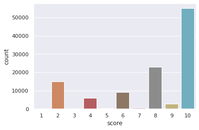

```python
sns.countplot(x = df_final['score']);
```

```python
df_final.groupby('product')['score'].count().sort_values(ascending=False).head(100)
```

```
product
Lenovo Vibe K4 Note (White,16GB)                                                                                             2452
Lenovo Vibe K4 Note (Black, 16GB)                                                                                            2021
OnePlus 3 (Graphite, 64 GB)                                                                                                  1461
OnePlus 3 (Soft Gold, 64 GB)                                                                                                 1390
Lenovo Vibe K5 (Gold, VoLTE update)                                                                                          1269
                                                                                                                             ...
Smartphone LG L90 D410                                                                                                        148
Asus ZenFone 2 Laser Smartphone, Display da 5", 16 GB, Dual SIM, Nero [Italia]                                                147
Apple iPhone SE (Gold, 16GB)                                                                                                  147
Apple iPhone 5 A1428 Factory Unlocked Cellphone, 16GB, Black                                                                  145
Asus ZE551ML-2A760WW Smartphone ZenFone 2 Deluxe, 5.5", 4 GB RAM, 64 GB, Intel Quad-Core Z3580, Dual SIM, Illusion Purple     145
Name: score, Length: 100, dtype: int64
```

```python
df_final.groupby('product')['score'].count().sort_values(ascending=False).tail(100)
```

```
product
Samsung i900 Omnia                   1
Siemens A55                          1
Siemens C45                          1
Siemens C65                          1
Samsung I9100 Galaxy S II (Black)    1
                                    ..
Nokia 6030                           1
Nokia 6070                           1
Sony Xperia S titanio                1
Nokia 6101                           1
3100 / 3120                          1
Name: score, Length: 100, dtype: int64
```

**Observations:**

Both item-item based and user-user based have almost similar RMSE value.

Most ratings are dominated/provided by Amazon Customers.

Most users have given the ratings 8 or 10. Next is low rating of 2.

Many products have been rated just once. This affects the prediction capability.

## **6. Predict score (average rating) for test users.**

```python
svdPredDF      = pd.DataFrame(svdPredictions)
itemItemPredDF = pd.DataFrame(ItemBasedKNNPred)
UserUserPredDF = pd.DataFrame(UserBasedKNNPred)

print("\nAverage Rating prediction for SVD:\n", svdPredDF.groupby('uid')['est'].mean().sort_values(ascending=False).head(5))
print("\nAverage Rating prediction for Item-Item KNNCF:\n",itemItemPredDF.groupby('uid')['est'].mean().sort_values(ascending=False).head(5))
print("\nAverage Rating prediction for User-User KNNCF:\n",UserUserPredDF.groupby('uid')['est'].mean().sort_values(ascending=False).head(5))
```

```
Average Rating prediction for SVD:
 uid
ÐÑÐ¸ÑÑÐ¸Ð½Ð°        9.789954
schreef                 9.629292
einem Kunden            9.528390
Jimmy                   9.460112
ÐÐ»ÐµÐºÑÐ°Ð½Ð´ÑÐ°    9.454069
Name: est, dtype: float64

Average Rating prediction for Item-Item KNNCF:
 uid
ÐÑÐ¸ÑÑÐ¸Ð½Ð°    9.844965
schreef             9.651551
rick2809            9.649345
Jose Luis           9.605710
Philippe            9.600000
Name: est, dtype: float64

Average Rating prediction for User-User KNNCF:
 uid
rick2809            10.000000
ÐÑÐ¸ÑÑÐ¸Ð½Ð°     9.967721
lahr2006             9.897059
Pasquale             9.862781
Samuel               9.755976
Name: est, dtype: float64
```

## **7. Report your findings and inferences.**

**Observations:**

Both item-item based and user-user based have similar RMSE value. SVD faired little better with lesser RMSE value.

Most ratings are dominated/provided by Amazon Customers indicating it may be the largest selling phone website in the world.

Most users have given the ratings 8 or 10. Next is low rating of 2.

Many products have been rated just once. This affects the prediction capability and thus suffer from grey sheep problem.

## **8. Try and recommend top 5 products for test users.**

```python
def get_top_5(predictions):
    # First map the predictions to each user.
    top_5 = defaultdict(list)
    for uid, iid, true_r, est, _ in predictions:
        top_5[uid].append((iid, est))

    # Then sort the predictions for each user and retrieve the k highest ones.
    for uid, user_ratings in top_5.items():
        user_ratings.sort(key=lambda x: x[1], reverse=True)
        top_5[uid] = user_ratings[:5]

    return top_5
```

```python
top_5 = get_top_5(ItemBasedKNNPred)

# Print the recommended items for each user
for uid, user_ratings in top_5.items():
    print(uid, [iid for (iid, _) in user_ratings])
```

```
Amazon Customer ['Motorola Moto X Play UK SIM-Free Smartphone - White', 'BlackBerry Z10 16Gb White WiFi Touchscreen Unlocked GSM QuadBand Cell Phone', 'Apple iPhone 5c (Blue, 8GB)', 'Huawei Ascend P7 Smartphone (5 Zoll (12,7 cm) Touch-Display, 16 GB Speicher, Android 4.4.2) weiÃ\x9f', 'Samsung T699 …
Peter ['Sim Free Samsung Galaxy S7 Edge Mobile Phone - Black.', 'HTC Mozart 7 Smartphone (9,4 cm (3,7 Zoll) Display, Touchscreen, 8 Megapixel Kamera, T-Mobile)', 'Samsung Galaxy A5 (2017) zwart / 32 GB', 'HTC One X White', 'Apple iPhone 7, 32Gb - Black']
ÐÐ½ÑÐ¾Ð½ ['Nokia Lumia 920 White', 'Nokia Lumia 920 White', 'Apple iPhone 5s 16GB (Ñ\x81ÐµÑ\x80Ñ\x8bÐ¹ ÐºÐ¾Ñ\x81Ð¼Ð¾Ñ\x81)', 'Apple iPhone 5s 16GB (Ñ\x81ÐµÑ\x80Ñ\x8bÐ¹ ÐºÐ¾Ñ\x81Ð¼Ð¾Ñ\x81)', 'Sony Xperia L (ÐºÑ\x80Ð°Ñ\x81Ð½Ñ\x8bÐ¹)']
Cliente Amazon ['Nokia 301', 'Nokia 301', 'Nokia 301', 'Asus ZenFone 2 Smartphone, 64 GB, Blu Fusion [Italia]', 'Nokia 301']
Daniel ['JIAYU G4S - Smartphone libre Android (pantalla 4.7", cÃ¡mara de 13 MP, 16 GB, 2 GB de RAM), negro', 'LG Electronics Google Nexus 5 Smartphone (4,95 Zoll (12,6 cm) Touch-Display, 16 GB Speicher, Android 4.4) weiÃ\x9f', 'Sony Xperia Z3 Compact - Smartphone libre Android (pantalla 4.6", cÃ¡mar…
Anonymous ['BlackBerry Torch 9800', 'Apple iPhone 7, 32Gb - Rose Gold', 'LG Chocolate Touch VX8575', 'Nokia Lumia 930', 'LG G2 Verizon VS980 White']
Max ['Samsung Omnia 7 I8700 Smartphone (10,1 cm (4 Zoll) AMOLED Display, Touchscreen, 5 Megapixel Kamera, Windows Phone 7) schwarz', 'Lenovo Motorola Moto G Smartphone (11,4 cm (4,5 Zoll) HD-Display, 5 Megapixel Kamera, 1,2 GHz Quad-Core-Prozessor, 16 GB interner Speicher, Android 4.3 OS) schwarz', …
e-bit ['Smartphone LG Optimus L9 P768', 'Smartphone LG Optimus L9 P768', 'Apple iPhone 6S 16GB', 'Apple iPhone 6S 16GB', 'Apple iPhone 6S 16GB']
anonym ['LG Chocolate KG800', 'Nokia 6150', 'Nokia 6301', 'Ericsson T68', 'Samsung S7710 Galaxy Xcover 2 Smartphone (10,2 cm (4 Zoll) Touchscreen, 1GHz, Dual-Core, 1GB RAM, 4GB, 5 Megapixel Kamera, Android 4.1) schwarz/rot']
Barbara ['Huawei P9 Lite Smartphone, LTE, Display 5,2â\x80\x9d FHD, IPS, Processore Kirin 650, 3 GB RAM, Fotocamera 13 MP, Nero, (Marchio TIM) [Versione Italia]', 'Microsoft Nokia 1616 Handy (UKW-Radio, Farbdisplay, Flashlight) ohne Vertrag, ohne Branding, kein Simlock schwarz', 'HTC Incredible S Sm…
silvia ['Lenovo Motorola Moto G Smartphone, 4,5 pollici display HD, processore Qualcomm, memoria 16GB, MicroSIM, Android 4.3 OS, fotocamera da 5 MP, Nero [Germania]', 'Samsung Galaxy S3 I9300 Blanco Libre', 'Huawei P8 Lite Smartphone, Display 5" IPS, Processore Octa-Core 1.5 GHz, Memoria Interna da …
Linda ['LG Electronics G2 Smartphone ( 13,2 cm (5,2 Zoll) Touchscreen, Quad-Core, 13 Megapixel Kamera, 16GB Speicher, Android 4.2) weiÃ\x9f', 'Samsung Galaxy S3, Red (AT&T)', 'LG Optimus G Pro E980', 'Sim Free Motorola Moto G 4th Generation Mobile Phone - Black', 'Samsung Galaxy S7 zwart / 32 GB']
Jay ['Asus Zenfone Max ZC550KL (16 GB)', 'Samsung Galaxy J3 (8GB)', 'Samsung Galaxy J3 (8GB)', 'Sim Free Samsung Galaxy S7 Mobile Phone - Black', 'Motorola Moto G 4G SIM-Free Smartphone - Black (8GB) - Discontinued by manufacturer']
Client d'Amazon ['Motorola Moto G 4G (2Ã¨me gÃ©nÃ©ration) Smartphone dÃ©bloquÃ© 4G (Ecran : 5 pouces - 8 Go - Simple SIM - Android 6.0 Marshmallow) Noir', 'Motorola Moto G 4G (2Ã¨me gÃ©nÃ©ration) Smartphone dÃ©bloquÃ© 4G (Ecran : 5 pouces - 8 Go - Simple SIM - Android 6.0 Marshmallow) Noir', 'Samsun…
M. ['Sony Ericsson W810i Fusion White Handy', 'Samsung Galaxy S7 zwart / 32 GB', 'Samsung Galaxy S5 mini Smartphone (4,5 Zoll (11,4 cm) Touch-Display, 16 GB Speicher, Android 4.4) gold', 'Blackberry Classic Smartphone (3,5 Zoll (8,9 cm) Touch-Display, 16 GB Speicher, Blackberry 10.3.1 OS) schwarz', …
Amazon Kunde ['Wileyfox Swift 4G Dual-SIM Smartphone (5,0 Zoll (12,70 cm) Display, 16 GB Speicher, Cyanogen OS 12.1) Sandstein-Schwarz', 'Microsoft Lumia 640 XL Dual-SIM LTE Smartphone (14,5 cm (5,7 Zoll) HD-LCD-Display, 1,2-GHz-Quad-Core-Prozessor, 13 Megapixel-Kamera, 3000 mAh Akku, 3G & 4G LTE, D…
Tim ['Samsung R355C Net 10 Unlimited', 'Samsung Galaxy S6 SM-G920F Factory Unlocked Cellphone, International Version, No Warranty 32GB, Gold', 'Lenovo Motorola Moto G 2. Generation Dual-Sim Smartphone (5 Zoll (12,7 cm) Touch-Display, 8 GB Speicher, Android 5.02) schwarz', 'HTC One X White', 'Huawei …
```

[output cut: 610 more lines]

## **9. Try other techniques (Example: cross validation) to get better results.**

```python
from surprise.model_selection import cross_validate

benchmark = []

# Iterate over all algorithms
for algorithm in [SVD(), KNNWithMeans()]:
    # Perform cross validation
    results = cross_validate(algorithm, data1, measures = ['RMSE'], cv=3, verbose=False)

    # Get results & append algorithm name
    tmp = pd.DataFrame.from_dict(results).mean(axis=0)
    tmp = tmp.append(pd.Series([str(algorithm).split(' ')[0].split('.')[-1]], index=['Algorithm']))
    benchmark.append(tmp)

pd.DataFrame(benchmark).set_index('Algorithm').sort_values('test_rmse')
```

```
Computing the msd similarity matrix...
Done computing similarity matrix.
Computing the msd similarity matrix...
Done computing similarity matrix.
Computing the msd similarity matrix...
Done computing similarity matrix.
```

| Algorithm | test_rmse | fit_time | test_time |
| --- | --- | --- | --- |
| SVD | 2.728091 | 1.412272 | 0.393659 |
| KNNWithMeans | 2.764901 | 0.348117 | 6.101487 |

## **10. In what business scenario you should use popularity based Recommendation Systems ?**

Popularity based recommendation systems should be used when a new customer subscribe to our service since we don't have their previous information/preferences/history. It can be used in below scenarios like recommending the :

- popular songs currently trending in the Music Apps.
- popular trend in fashion industry.
- popular destination tour for vacation.
- popular movies watched by many people.

## **11. In what business scenario you should use CF based Recommendation Systems ?**

Collaborative filtering is useful in scenarios where we already have information on a customer base. This system finds similarity between customers based on the products they have rated.

CF can be applied in cases like:

- items that a user views in an online store but not neccesarily buys.
- how many times the user visited the item.
- how many times the user purchased the item.
- keeping a track of videos he likes/dislikes.

## **12. What other possible methods can you think of which can further improve the recommendation for different users ?**

While using collaborative filtering methods, we tend to suffer from gray sheep and cold start problems. In order to avoid this, it is better use a hybrid recommendation system to improve the recommendations. Hybrid recommendation system combined with CF methods is more likely to provide better recommendations on industry based datasets. Netflix is an excellent example of hybrid R-system (like comparing the watching and searching habits of users and finding similar users.)